# Tarea Corta 2

Esteban Arroyo

## Respuestas de la Tarea Corta 2 del Taller Estadística para Antropología Física

Para esta tarea, usaremos el data set osteométrico de Goldman de libre uso en el siguiente link http://web.utk.edu/~auerbach/GOLD.htm

### 1.- Para esta tarea, van a seleccionar tres variables

- Dos variables contínuas y otra categórica (Sex ó Location)

Cargamos las librerías a utilizar

```r
library(readxl)
library(ggplot2)
library(nortest)
library(RVAideMemoire)
library(pander)
```

Cargamos la base de Goldman

```r
base <- read_excel("Goldman.xls")
```

Selecionamos las variables “Sex”, “RHMLD”, “LHMLD” y creamos una nueba base

```r
base_selec <- base[ , c("Sex", "RHMLD", "LHMLD")]
```

### 2.- Dependiendo de su selección, hay que hacer un preproceso de limpieza

```r
sum(is.na(base_selec))  #verificamos si hay vacios (NA)
```

```
## [1] 297
```

Observamos que hay 297 vacíos o NA, por tanto, procedemos a aliminarlos

```r
base_selec <- na.omit(base_selec)  #Eliminamos los vacíos
```

Corregimos o ajustamos los valores de Sex

```r
base_selec$Sex <- ifelse(base_selec$Sex == '0?', 0, base_selec$Sex)
base_selec$Sex <- ifelse(base_selec$Sex == '1?', 1, base_selec$Sex)
pander(table(base_selec$Sex))  #Revisamos si se hicieron los ajustes
```

| 0 | 1 |
| --- | --- |
| 826 | 452 |

Factorizamos la variable Sex, es decir, le agregamos las etiquetas correspondientes

```r
base_selec$Sex <- factor(base_selec$Sex, labels = c("Mas","Fem"))
pander(table(base_selec$Sex))  #Volvemos a revisar
```

| Mas | Fem |
| --- | --- |
| 826 | 452 |

### 3.- Realizar el siguiente proceso estadístico

- Para las dos variables contínuas realizar gráfico de histograma y Q-Q plot

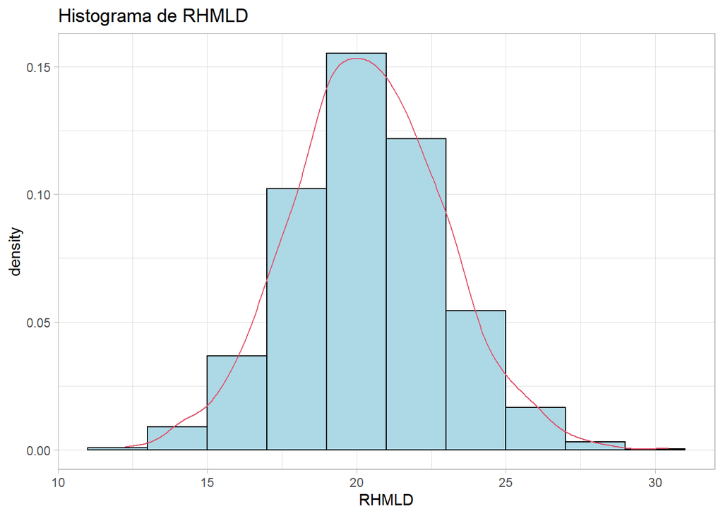

```r
ggplot(data=base_selec, aes(x=RHMLD)) +
  geom_histogram(aes(y = ..density..), col='black', fill= "lightblue", binwidth=2)+
  geom_density(colour = 2)+theme_light() + ggtitle("Histograma de RHMLD")
```

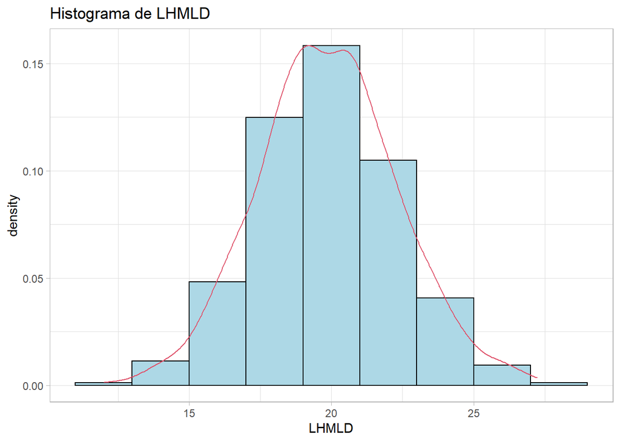

```r
ggplot(data=base_selec, aes(x=LHMLD)) +
  geom_histogram(aes(y = ..density..), col='black', fill= "lightblue", binwidth=2)+
  geom_density(colour = 2)+theme_light() + ggtitle("Histograma de LHMLD")
```

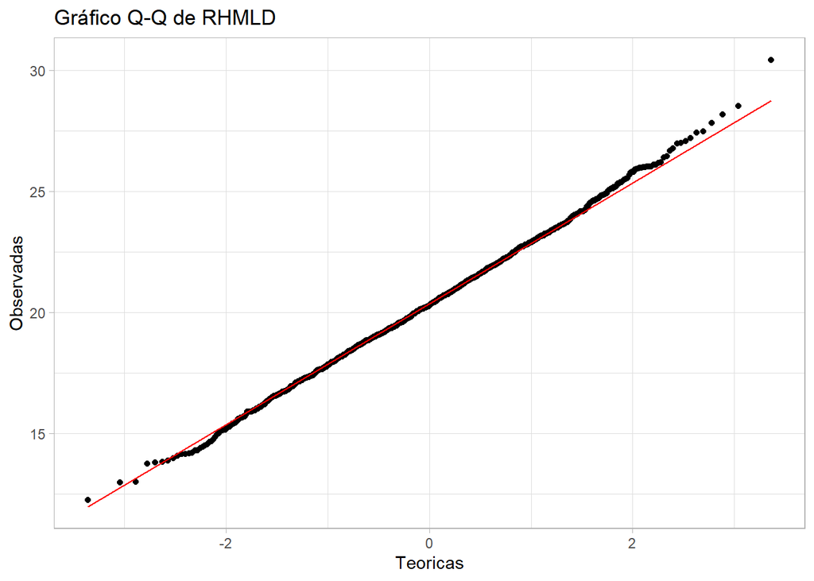

```r
ggplot(data=base_selec, aes(sample = RHMLD)) +
  stat_qq() + stat_qq_line(col="red")+
  xlab('Teoricas')+ylab('Observadas')+theme_light() + ggtitle("Gráfico Q-Q de RHMLD")
```

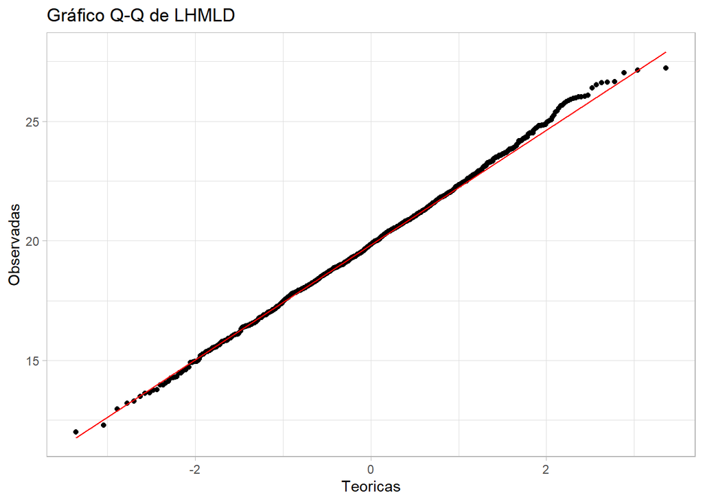

```r
ggplot(data=base_selec, aes(sample = LHMLD)) +
  stat_qq() + stat_qq_line(col="red")+
  xlab('Teoricas')+ylab('Observadas')+theme_light() + ggtitle("Gráfico Q-Q de LHMLD")
```

Observamos que de forma cualitativa, en los gráficos de histogramas como los Q-Q plots, los datos se asemejan mucho a la distribución normal.

- Realizar los test de Shapiro-Wilk y Kolmogorov-Smirnov (c/corrección de Lilliefors) y evaluar cual dá mejor

```r
pander(lillie.test(base_selec$RHMLD))
```

Lilliefors (Kolmogorov-Smirnov) normality test: `base_selec$RHMLD`

| Test statistic | P value |
| --- | --- |
| 0.01305 | 0.8624 |

```r
pander(lillie.test(base_selec$LHMLD))
```

Lilliefors (Kolmogorov-Smirnov) normality test: `base_selec$LHMLD`

| Test statistic | P value |
| --- | --- |
| 0.01528 | 0.6659 |

```r
pander(shapiro.test(base_selec$RHMLD))
```

Shapiro-Wilk normality test: `base_selec$RHMLD`

| Test statistic | P value |
| --- | --- |
| 0.999 | 0.7061 |

```r
pander(shapiro.test(base_selec$LHMLD))
```

Shapiro-Wilk normality test: `base_selec$LHMLD`

| Test statistic | P value |
| --- | --- |
| 0.9989 | 0.6118 |

En ambos casos las pruebas se ajustan a la normal, sin embargo nos quedamos con la prueba Kolmogorov-Smirnov con la corrección de Lilliefors, ya que es la más apropiada para muestras mayores de 50.

- De ser necesario haga las transformaciones pertinentes y repita los test.

En estas dos variables en particular, no es necesario ya que en ninguno de los test se rechazó la Ho, es decir, en todos los casos, se ajustan a la normal.

Sin embargo, las pruebas de transformación que se pueden realizar (para otras variables) son:

- lillie.test(sqrt(base_selec$RHMLD))
- lillie.test(log(base_selec$RHMLD))
- lillie.test(1/(base_selec$RHMLD)^2)
- lillie.test(1/(base_selec$RHMLD)^3)
- lillie.test(base_selec$RHMLD^2)
- lillie.test(base_selec$RHMLD^3)
- lillie.test(base_selec$RHMLD^4)
- lillie.test(sqrt(base_selec$LHMLD))
- lillie.test(log(base_selec$LHMLD))
- lillie.test(1/(base_selec$LHMLD)^2)
- lillie.test(1/(base_selec$LHMLD)^3)
- lillie.test(base_selec$LHMLD^2)
- lillie.test(base_selec$LHMLD^3)
- lillie.test(base_selec$LHMLD^4)

### Finalmente use la función byf.shapiro() para evaluar la normalidad de cada una de las variables contínuas por la variable categórica seleccionada (Sex ó Location)

Para este caso usaremos la variable Sex

```r
pander(byf.shapiro(RHMLD~Sex, data=base_selec))
```

- **method**: Shapiro-Wilk normality tests
- **data.name**: RHMLD by Sex
- **tab**:

  |  | W | p-value |
  | --- | --- | --- |
  | **Mas** | 0.9965 | 0.06629 |
  | **Fem** | 0.9979 | 0.8524 |

```r
pander(byf.shapiro(LHMLD~Sex, data=base_selec))
```

- **method**: Shapiro-Wilk normality tests
- **data.name**: LHMLD by Sex
- **tab**:

  |  | W | p-value |
  | --- | --- | --- |
  | **Mas** | 0.9969 | 0.114 |
  | **Fem** | 0.9974 | 0.716 |

```r
pander(byf.shapiro(sqrt(RHMLD)~Sex, data=base_selec))
```

- **method**: Shapiro-Wilk normality tests
- **data.name**: sqrt(RHMLD) by Sex
- **tab**:

  |  | W | p-value |
  | --- | --- | --- |
  | **Mas** | 0.999 | 0.9391 |
  | **Fem** | 0.9946 | 0.1094 |

Observamos que ahora si se ajustan.

### En caso que la función byf.shapiro() del paquete no funcione RVAideMemoire, producto de un error en la instalación, se peude proceder de la siguiente manera:

```r
#Creamos una nueva base solo para sexo femenino
base_selec_fem <- base_selec[base_selec$Sex=="Fem" , ]

#Posteriormente realizamos la prueba con la función shapiro.test() para cada variable
pander(shapiro.test(base_selec_fem$RHMLD))
```

Shapiro-Wilk normality test: `base_selec_fem$RHMLD`

| Test statistic | P value |
| --- | --- |
| 0.9979 | 0.8524 |

```r
pander(shapiro.test(base_selec_fem$LHMLD))
```

Shapiro-Wilk normality test: `base_selec_fem$LHMLD`

| Test statistic | P value |
| --- | --- |
| 0.9974 | 0.716 |

```r
#Repetimos el proceso para el sexo masculino
base_selec_mas <- base_selec[base_selec$Sex=="Mas" , ]
pander(shapiro.test(base_selec_mas$RHMLD)) # como en este caso el p-valor es 0.06629, lo ajustamos por la raiz cuadrada
```

Shapiro-Wilk normality test: `base_selec_mas$RHMLD`

| Test statistic | P value |
| --- | --- |
| 0.9965 | 0.06629 |

```r
pander(shapiro.test(sqrt(base_selec_mas$RHMLD)))  #Aqui vemos el se ajusta la normal
```

Shapiro-Wilk normality test: `sqrt(base_selec_mas$RHMLD)`

| Test statistic | P value |
| --- | --- |
| 0.999 | 0.9391 |

```r
pander(shapiro.test(base_selec_mas$LHMLD))
```

Shapiro-Wilk normality test: `base_selec_mas$LHMLD`

| Test statistic | P value |
| --- | --- |
| 0.9969 | 0.114 |